# BIOST 561: Homework 1

Due date: 7:00pm on Monday, April 14th, 2025

```r
knitr::opts_chunk$set(
  collapse = TRUE,
  comment = "#>"
)



set.seed(10)
```

# Instructions

These instructions are essential, so please read them all carefully.

- Submit your homework as both the RMarkdown (`.Rmd`) file and HTML file on your GitHub page. (More on this later, as the first homework will guide you on how to do this.)
- Please answer the question prompt and show your code (inline). That is, all your code should be visible in the knitted chunks.
- To complete this homework, you may write in the `HW1.Rmd` file. (It is recommended to complete this homework in R Studio, where clicking the `Knit` button would knit your homework.)

# Disclosures

- Please disclose below who you collaborated with and if you’ve used ChatGPT (or any comparable AI tool) to what extent when completing this homework. See the syllabus for the course expectations.

# Q0: Survey

**Intent**: This question is simply for course logistics and for the course instructor to get to know you.

- **Question 0A**: Please let me know your preferred name and preferred pronouns.

Jordan Rodriguez, he/him

- **Question 0B**: Please read the syllabus in its entirety and write, “I have read and understood the entire syllabus,” for this question. If you have any questions about the syllabus (for example, on the homework submission policy or collaboration policy), you may ask them here.

I have read and understood the enitre syllabus

- **Question 0C**: If any, please briefly describe the courses you have taken at UW that involve coding (in any language) so far and how familiar/comfortable you are in coding in R. (Note: I do not expect you to have taken any such courses already.)

I fell very familiar with R

- **Question 0D**: What do you hope to learn from this course? (It is alright if you leave this blank, but it would be helpful to hear your thoughts.)

I’m eager to learn the software-engineering perspective and how to automate processes.

# Q1: Setting up an R package and GitHub

**Intent**: This section is not a question but to guide you step-by-step on how to make an R package and a GitHub, which will be critical for this course. This question will be challenging for students who are not familiar with R Studio or GitHub, so please ask the instructor questions.

Please read and walk through https://docs.google.com/document/d/1sB5qwkeOWnCU-UUkHxOjqUTep0kgpvUi7qtHo7eV8oU/edit?usp=sharing, as we have mentioned in class. Upon completion of this walkthrough, to get full marks for this question, you should have:

1. Created a GitHub account,
2. Created a private GitHub repository called `UWBiost561`,
3. Created an R package, which is located in your GitHub repository `UWBiost561`,
4. Created a vignette, which includes both `HW1.Rmd` and `HW1.html` under the `vignettes` folder, in your GitHub repository `UWBiost561`,
5. Added the username `linnykos` as a Collaborator to your GitHub repository `UWBiost561`.

**Note**: If you do not have a lot of familiarity with R Studio or GitHub, this question *will* be quite challenging (even though all you’re doing is following through a walkthrough). Please start this early if you feel nervous about this because your instructor (Kevin) can better help you if you give him ample time and come to office hours.

(You do not need to write anything for this question.)

# Q2: Simulating the Central Limit Theorem

**Intent**: This question is a simple coding exercise to demonstrate familiarity with how to do basic coding in R.

Load in the `generate_data` function using the following code (all one line).

```r
source("https://raw.githubusercontent.com/linnykos/561_s2025_public/main/HW1_files/generate_data.R")
```

This code sources the `generate_data` function into your current R workspace.

**Question 2A**: Read the function (either at the URL provided or by typing `generate_data` into your console), and in one to three sentences, describe the input and output of the provided function and what the function is doing. You may use equations if needed.

The function accepts a positive integer n as input and returns a numeric vector of length nn. First, it generates an index vector (idx_vec) by randomly sampling n digits from 1 to 3 with replacement. Then, for each digit in idx_vec, it draws a corresponding random sample from a specific distribution: a normal distribution N(10,1) for each 1, a gamma distribution for each 2, and a chi-square distribution for each 3. Finally, the function stores these random values in the positions of the output vector (sample_vec) that correspond to their associated digit in idx_vec.

**Question 2B**: We will now be using the `generate_data` function. Observe that if we run the following code, we would compute a (random, empirical) mean of the a dataset with `n=10` samples:

```r
set.seed(1)
mean(generate_data(n=10))
```

```
#> [1] 5.199818
```

Repeat the above code 10,000 times (i.e., 10,000 trials, but keeping `n=10` for each trial), and plot a histogram of the 10,000 different empirical means with 100 breaks (i.e., `breaks = 100`). Repeat this process for `n` with values of 1, 2, 3, 5, and 100, and plot these six histograms in order of increasing `n`.

Figure 1 shows the desired plot you aim to reproduce. In particular, reproduce the X- and Y-labels, the title of the plot, and the plot layout. (Hint: You might find the `par` function useful, especially the `mar` and `mfrow` arguments, as well as the `paste` function. See the documentation for `par`.)

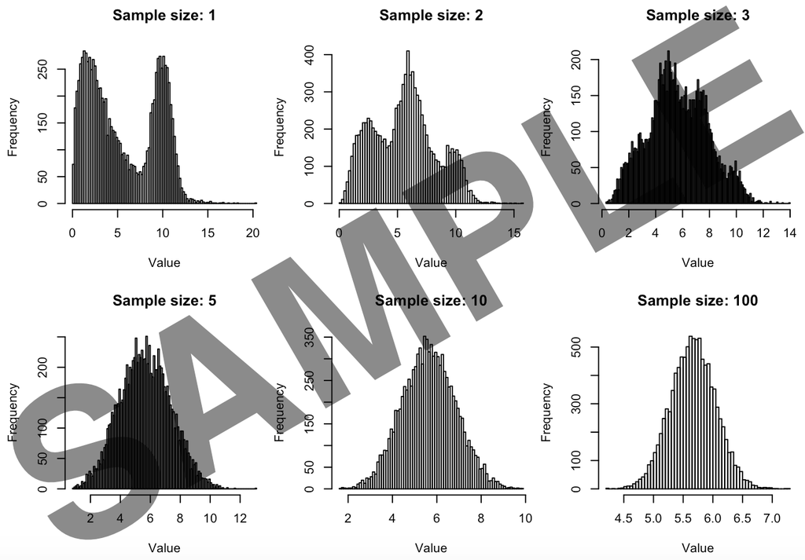

Figure 1: The figure you are trying to reproduce (without the Sample watermark) in Question 2B, barring the dimensions/proportions of the figure itself and randomness inherent to the simulation.

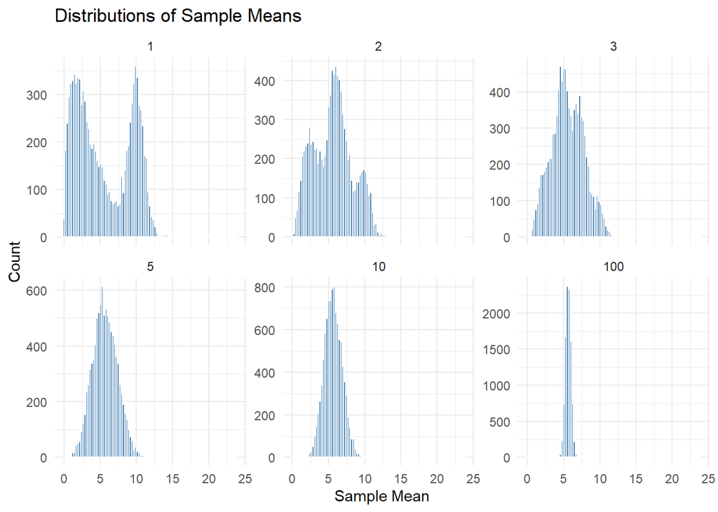

```r
library(ggplot2)
results_ = matrix(NA,10000*6,2)
n_ = c(1,2,3,5,10,100)
results_[,1] = rep(n_, each = 10000)
colnames(results_) = c("n","value")

for (k in 1:6){
  for (i in 1:10000){
    set.seed(i)
    row_index = (k - 1) * 10000 + i
    results_[row_index, 2] = mean(generate_data(n = n_[k]))
  }
}

dat1 = as.data.frame(results_)
ggplot(dat1, aes(x = value)) +
  geom_histogram(bins = 100, fill = "steelblue", color = "white") +
  facet_wrap(~ n, scales = "free_y") +
  theme_minimal() +
  labs(title = "Distributions of Sample Means",
       x = "Sample Mean",
       y = "Count")
```

**Question 2C**: In one to three sentences, write how the plot you reproduced helps to verify the Central Limit Theorem.

As we increase the sample size, the distribution of the sample mean converges to a normal distribution

# Q3: Basic data analysis

**Intent**: This question is a simple data analysis to demonstrate familiarity with how to perform basic operations in R.

In this question, we’ll load a simple dataset related to Alzheimer’s Disease (AD) research. The data originates from a single-cell database from [this study](https://portal.brain-map.org/explore/seattle-alzheimers-disease). However, since this is the first homework, we’ll mainly work with donor-level data instead of the cell-level data.

```r
df <- read.csv("https://raw.githubusercontent.com/linnykos/561_s2025_public/main/HW1_files/sea-ad.csv")

head(df)
```

```
#>     Donor.ID Age.at.Death    Sex APOE4.Status Cognitive.Status Last.CASI.Score    Braak
#> 1 H19.33.004           80 Female            N      No dementia              85 Braak IV
#> 2 H20.33.001           82   Male            N      No dementia              97 Braak IV
#> 3 H20.33.002          90+ Female            N      No dementia              93 Braak IV
#> 4 H20.33.004           86   Male            Y         Dementia              80  Braak V
#> 5 H20.33.005          90+ Female            N      No dementia              94 Braak IV
#> 6 H20.33.008          90+ Female            Y      No dementia              92  Braak V
```

```r
summary(df)
```

```
#>    Donor.ID         Age.at.Death           Sex            APOE4.Status       Cognitive.Status   Last.CASI.Score
#>  Length:84          Length:84          Length:84          Length:84          Length:84          Min.   :66.00
#>  Class :character   Class :character   Class :character   Class :character   Class :character   1st Qu.:80.00
#>  Mode  :character   Mode  :character   Mode  :character   Mode  :character   Mode  :character   Median :89.00
#>                                                                                                 Mean   :87.32
#>                                                                                                 3rd Qu.:95.00
#>                                                                                                 Max.   :99.00
#>                                                                                                 NA's   :15
#>     Braak
#>  Length:84
#>  Class :character
#>  Mode  :character
#>
#>
#>
#>
```

Here are brief descriptions of each variable:

- `Donor.ID`: The anonymized ID of the donor who donated their brain to AD research
- `Age.at.Death`: The age of the donor when they passed away
- `Sex`: The biological sex of the donor. (Kevin’s comment: In this study, it seems like this is strictly only `Male` or `Female`…?)
- `APOE4.Status`: `Y` (for yes) or `N` (for no) if the donor has a particular genetic variant that is known to be a risk factor for AD
- `Cognitive.Status`: Whether the donor has dementia or not based on a wide array of cognitive assessments before death
- `Last.CASI.Score`: The last score the donor had, measured via CASI (a specific set of cognitive questions), before death
- `Braak`: Different severities of neuropathology based on the donor’s brain tissue, extracted after the donor’s consent and death

Hopefully, this is a reminder to carefully describe your study variables in any dataset you publish or collaborate on!

**Question 3A**: Describe, in two to four sentences, what the `head(df)` and `summary(df)` results display.

prints the first 6 observations allong with variable names

**Question 3B**: Use a simple function to print out the dimensionality of `df` (i.e., how many rows and columns there are). What is the class of `df`?

there are 84 observations and 7 variables. The class is a data frame

**Question 3C**: You’ll note that in `summary(df)`, the variable `Age.at.Death` is a `character`, even though it should be a numeric. This is because there are values of `90+`. As a simple diagnostic, 1) replace all the `90+` values in `df$Age.at.Death` with `90`, 2) convert `df$Age.at.Death` from a character to a numeric, and 3) plot a histogram of `df$Age.at.Death`.

Figure 2 shows the desired plot you aim to reproduce.

```r
table(df$Age.at.Death)
```

```
#>
#>  65  68  69  70  72  75  77  78  80  81  82  83  84  85  86  87  88  89 90+
#>   1   1   1   1   1   2   1   1   2   3   4   3   2   2   3   2   5   3  46
```

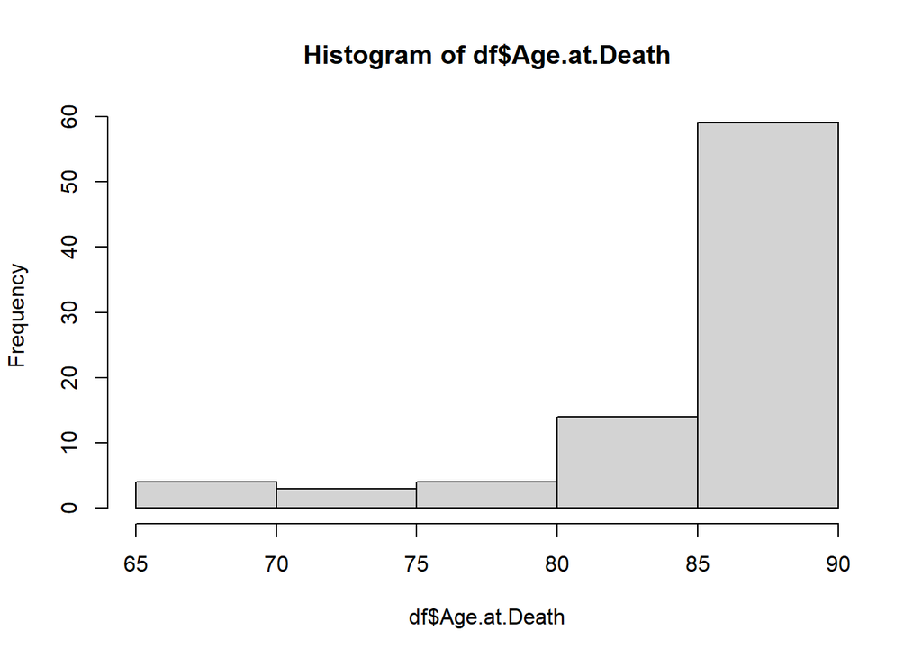

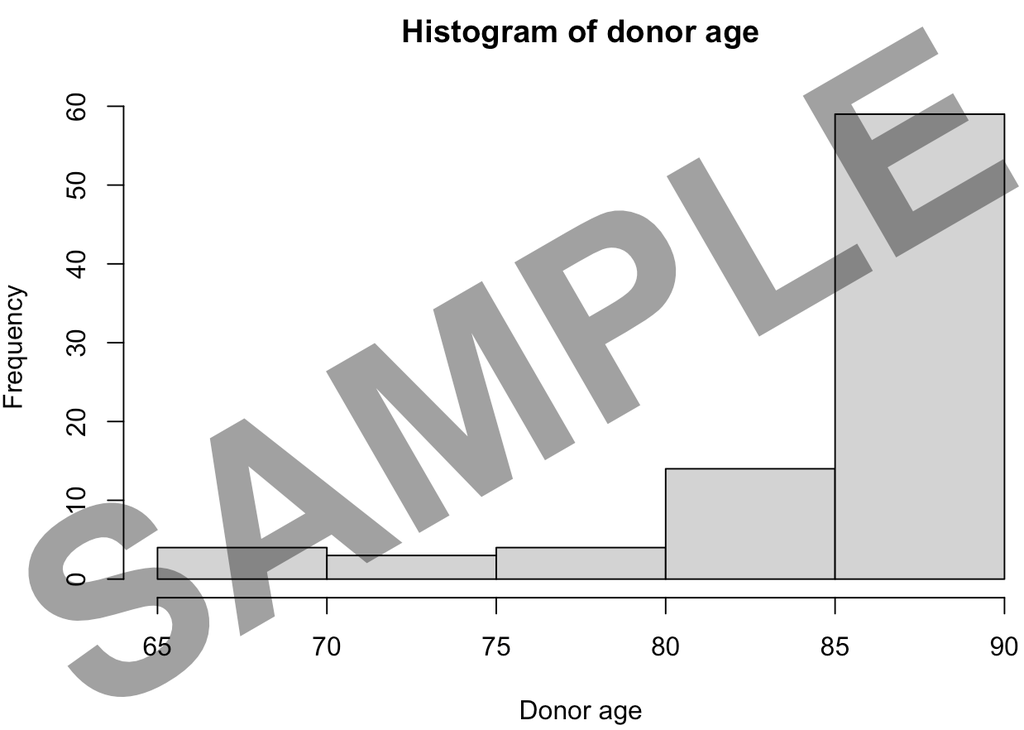

Figure 2: The figure you are trying to reproduce (without the Sample watermark) in Question 3C, barring the dimensions/proportions of the figure itself.

```r
df$Age.at.Death = as.numeric(substr(df$Age.at.Death,1,2))

hist(df$Age.at.Death )
```

**Question 3D**: The `summary()` function is much more useful when the columns of `df` are factors, not characters. Write some lines of code to convert the variables `Sex`, `APOE4.Status`, `Cognitive.Status`, and `Braak` to be factors. (This should take less than 10 lines of code.)

```r
names(df)
```

```
#> [1] "Donor.ID"         "Age.at.Death"     "Sex"              "APOE4.Status"     "Cognitive.Status" "Last.CASI.Score"
#> [7] "Braak"
```

```r
df[,3:5] = lapply(df[,3:5], as.factor)
```

**Question 3E**: With this new version of `df`, after finishing the previous questions, show the result of `summary(df)`.

```r
summary(df)
```

```
#>    Donor.ID          Age.at.Death       Sex     APOE4.Status    Cognitive.Status Last.CASI.Score    Braak
#>  Length:84          Min.   :65.00   Female:51   N:59         Dementia   :42      Min.   :66.00   Length:84
#>  Class :character   1st Qu.:83.75   Male  :33   Y:25         No dementia:42      1st Qu.:80.00   Class :character
#>  Mode  :character   Median :90.00                                                Median :89.00   Mode  :character
#>                     Mean   :86.26                                                Mean   :87.32
#>                     3rd Qu.:90.00                                                3rd Qu.:95.00
#>                     Max.   :90.00                                                Max.   :99.00
#>                                                                                  NA's   :15
```

Figure 3 shows the desired output you aim to reproduce.

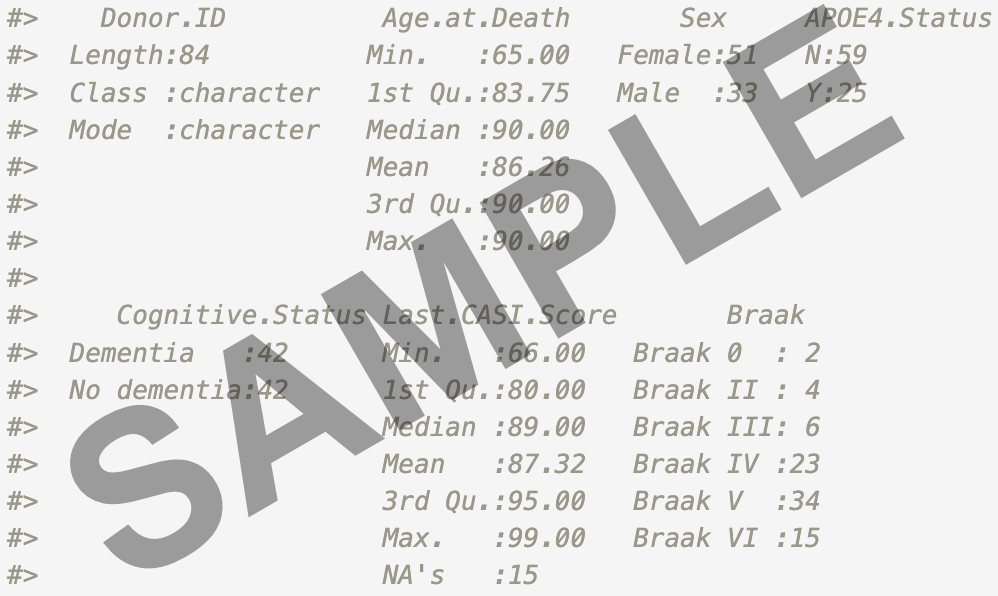

Figure 3: The intended output of Question 3E.

In one sentence, describe how the summary here (in Question 3E) is more informative than the summary shown at the start of Question 3.

it provides how many observations per level are in factor variables and the distribution of numeric variables

**Question 3F**: Using the `table()` function, display the relation between `Braak` and `Cognitive.Status`. Please look at `?table` (for the documentation of `table()`) if you are unfamiliar with this function.

```r
table(df$Braak, df$Cognitive.Status)
```

```
#>
#>             Dementia No dementia
#>   Braak 0          0           2
#>   Braak II         2           2
#>   Braak III        2           4
#>   Braak IV         4          19
#>   Braak V         20          14
#>   Braak VI        14           1
```

**Question 3G**: This question will be slightly challenging. The `table()` function is not as useful when there are many unique values (such as in `Last.CASI.Score`). To overcome this, look up the documentation for the `cut` and `quantile` functions. The goal is to use the `table()`, `cut()`, and `quantile()` to show the relation of the quantiles of `Last.CASI.Score` with `Cognitive.Status`. You will want to use `na.rm=TRUE` when using the `quantile()` function.

```r
quantiles <- quantile(df$Last.CASI.Score, probs = seq(0, 1, 0.25), na.rm = TRUE)
casi_quantile_group <- cut(df$Last.CASI.Score, breaks = quantiles, include.lowest = TRUE)
table(casi_quantile_group, df$Cognitive.Status)
```

```
#>
#> casi_quantile_group Dementia No dementia
#>             [66,80]       17           1
#>             (80,89]       10           8
#>             (89,95]        2          15
#>             (95,99]        3          13
```

Figure 4 shows the desired output you aim to reproduce.

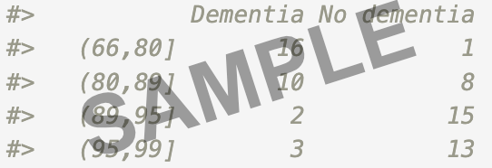

Figure 4: The intended output of Question 3G.

In one to two sentences, describe what you can learn from the relation between `Last.CASI.Score` and `Cognitive.Status` based on this result.

the lower the score, the higher the risk of dementia

# Q4: Pushing the homework onto GitHub

**Intent**: This section is not a question but a guide on submitting your homework. This procedure will be the expectation for all future homeworks.

Now that you have completed this homework, all that’s remaining is to push this homework onto your `UWBiost561` GitHub repository. To do this, please ensure:

1. Your file is named `HW1.Rmd`. (This current homework file you are writing in will replace the initial `HW1.Rmd` you made when you completed the walkthrough in Question 1.)
2. Your file is in the `vignettes` folder in your `UWBiost561` R package.
3. You push your two files, `HW1.Rmd` and `HW1.html` (the latter is the knitted HTML file) onto your GitHub repository.
4. Double-check that you can see both files online on github.com when you look at your repository.
5. *LASTLY*: Upload `HW1.html` to Canvas under “Assignment 1”. (This is for university-wide policy, but also helps me keep track of completion status of homeworks via Canvas.)

Again, ensure the username `linnykos` is added to your private GitHub repository. And with that, you’re done! (For future homeworks, you will be “submitting” your homeworks like this.)

(You do not need to write anything for this question.)

# Q5: Feedback (Optional)

This “question” is an additional way for students to communicate with instructors. You could include positive feedback about topics you enjoyed learning this module, critiques about the course difficulty/pacing, or some questions/confusions you had about course material. Your feedback can help us shape the course for the rest of this quarter and future years. Please be mindful and polite when providing feedback. You may leave this question blank.

Despite being a multi-step process, I liked how clear were the instructions. I had experience using github desktop for windows but not using it in R sudio directly! Is interesting. Also appreciate that the data analysis section was minimal.